# Prosper Loan Data EDA by SEKHAR CHEBOLU

```
##  [1] "Term"                      "LoanStatus"
##  [3] "BorrowerRate"              "EstimatedEffectiveYield"
##  [5] "EstimatedReturn"           "ProsperRating..numeric."
##  [7] "ListingCategory..numeric." "BorrowerState"
##  [9] "EmploymentStatusDuration"  "IsBorrowerHomeowner"
## [11] "CreditScoreRangeLower"     "CreditScoreRangeUpper"
## [13] "DebtToIncomeRatio"         "IncomeRange"
## [15] "StatedMonthlyIncome"       "LoanOriginalAmount"
## [17] "LoanOriginationDate"       "LoanOriginationQuarter"
## [19] "MonthlyLoanPayment"        "Investors"
```

# Description of Variables

Three new variables have been created

21. **LoanOriginationYear** - Year in which the loan was originated. This is created from the Loan Origination date.
22. **LoanOriginationMonth** - The month in which the loan was originated. This is created from the Loan Origination date.
23. **NewDebtToIncomeRatio** - This is the new Debt to Income Ratio after the current monthly loan payment is factored in. This is calculated by multiplying the current Debt to Income Ration with the monthly income and finding the annual income. The loan original amount is added to this annual income. This is divided by annual income to find the new debt to income ratio.

```
##       Term                       LoanStatus     BorrowerRate
##  Min.   :12.00   Current              :56576   Min.   :0.0000
##  1st Qu.:36.00   Completed            :38074   1st Qu.:0.1340
##  Median :36.00   Chargedoff           :11992   Median :0.1840
##  Mean   :40.83   Defaulted            : 5018   Mean   :0.1928
##  3rd Qu.:36.00   Past Due (1-15 days) :  806   3rd Qu.:0.2500
##  Max.   :60.00   Past Due (31-60 days):  363   Max.   :0.4975
##                  (Other)              : 1108
##  EstimatedEffectiveYield EstimatedReturn  ProsperRating..numeric.
##  Min.   :-0.183          Min.   :-0.183   Min.   :1.000
##  1st Qu.: 0.116          1st Qu.: 0.074   1st Qu.:3.000
##  Median : 0.162          Median : 0.092   Median :4.000
##  Mean   : 0.169          Mean   : 0.096   Mean   :4.072
##  3rd Qu.: 0.224          3rd Qu.: 0.117   3rd Qu.:5.000
##  Max.   : 0.320          Max.   : 0.284   Max.   :7.000
##  NA's   :29084           NA's   :29084    NA's   :29084
##  ListingCategory..numeric. BorrowerState   EmploymentStatusDuration
##  Min.   : 0.000            CA     :14717   Min.   :  0.00
##  1st Qu.: 1.000            TX     : 6842   1st Qu.: 26.00
##  Median : 1.000            NY     : 6729   Median : 67.00
##  Mean   : 2.774            FL     : 6720   Mean   : 96.07
##  3rd Qu.: 3.000            IL     : 5921   3rd Qu.:137.00
##  Max.   :20.000                   : 5515   Max.   :755.00
##                            (Other):67493   NA's   :7625
##  IsBorrowerHomeowner CreditScoreRangeLower CreditScoreRangeUpper
##  False:56459         Min.   :  0.0         Min.   : 19.0
##  True :57478         1st Qu.:660.0         1st Qu.:679.0
##                      Median :680.0         Median :699.0
##                      Mean   :685.6         Mean   :704.6
##                      3rd Qu.:720.0         3rd Qu.:739.0
##                      Max.   :880.0         Max.   :899.0
##                      NA's   :591           NA's   :591
##  DebtToIncomeRatio         IncomeRange    StatedMonthlyIncome
##  Min.   : 0.000    $25,000-49,999:32192   Min.   :      0
##  1st Qu.: 0.140    $50,000-74,999:31050   1st Qu.:   3200
##  Median : 0.220    $100,000+     :17337   Median :   4667
##  Mean   : 0.276    $75,000-99,999:16916   Mean   :   5608
##  3rd Qu.: 0.320    Not displayed : 7741   3rd Qu.:   6825
##  Max.   :10.010    $1-24,999     : 7274   Max.   :1750003
##  NA's   :8554      (Other)       : 1427
```

[output cut: 9 more lines]

```
##  Min.   :   0.0     Min.   :   1.00   Min.   :2005
##  1st Qu.: 131.6     1st Qu.:   2.00   1st Qu.:2008
##  Median : 217.7     Median :  44.00   Median :2012
##  Mean   : 272.5     Mean   :  80.48   Mean   :2011
##  3rd Qu.: 371.6     3rd Qu.: 115.00   3rd Qu.:2013
##  Max.   :2251.5     Max.   :1189.00   Max.   :2014
##
##  LoanOriginationMonth NewDebtToIncomeRatio
##  Min.   : 1.000       Min.   : 0.000
##  1st Qu.: 3.000       1st Qu.: 0.240
##  Median : 7.000       Median : 0.357
##  Mean   : 6.592       Mean   : 0.427
##  3rd Qu.:10.000       3rd Qu.: 0.501
##  Max.   :12.000       Max.   :10.010
##                       NA's   :8554
```

# Univariate Plots Section

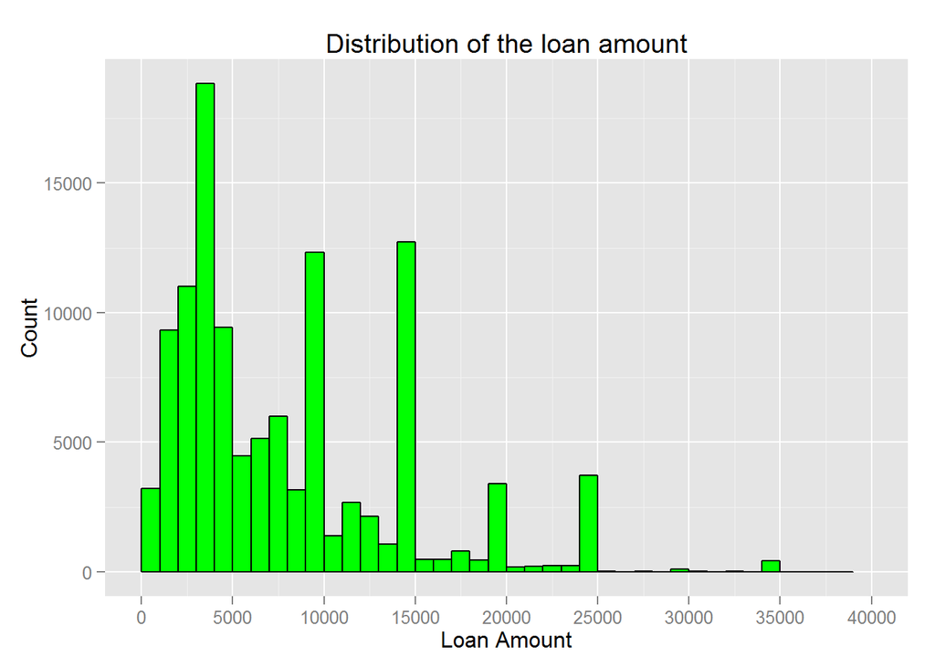

```r
summary(loan_data$LoanOriginalAmount)
```

```
##    Min. 1st Qu.  Median    Mean 3rd Qu.    Max.
##    1000    4000    6500    8337   12000   35000
```

```r
table(loan_data$LoanOriginalAmount < 4000)
```

```
##
## FALSE  TRUE
## 85872 28065
```

```r
table(loan_data$LoanOriginalAmount < 5000)
```

```
##
## FALSE  TRUE
## 69103 44834
```

We can see that the the peaks in the loan amounts are at values which are multiples of $5000 i.e. $5000, $10,000, $25,000 and even $35,0000. The maximum number of loans are in the range of $3000 to $5000. ~40% of loans are below $5000.

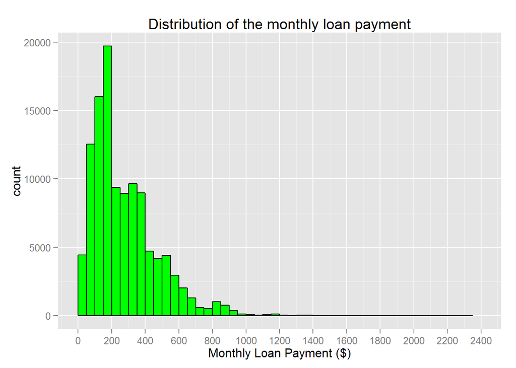

```r
summary(loan_data$MonthlyLoanPayment)
```

```
##    Min. 1st Qu.  Median    Mean 3rd Qu.    Max.
##     0.0   131.6   217.7   272.5   371.6  2252.0
```

```r
table(loan_data$MonthlyLoanPayment>1000)
```

```
##
##  FALSE   TRUE
## 113493    444
```

The distribution of the monthly loan payments is positively skewed at the first glance. There are some outlier values which are causing the graph to look like this. As can be seen there are only 444 loans (~0.4%) whose monthly payment is greater than $1000.

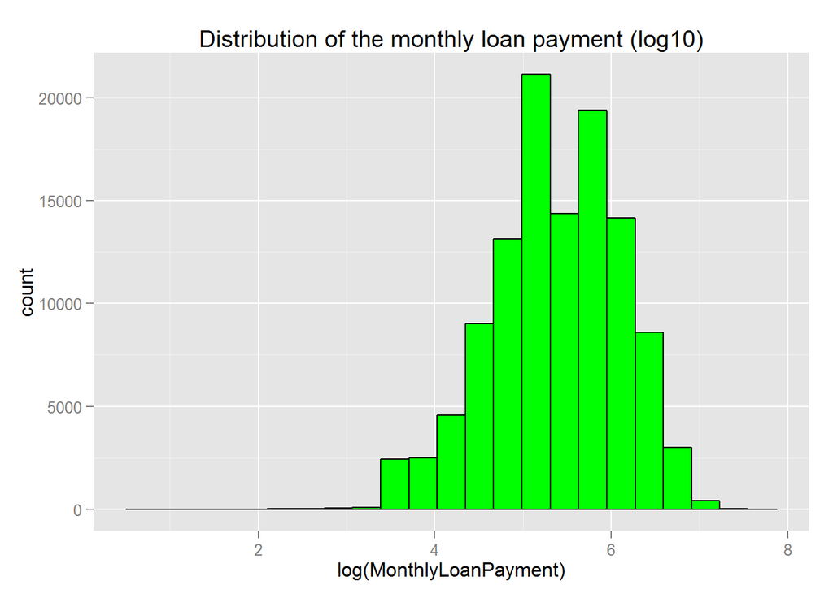

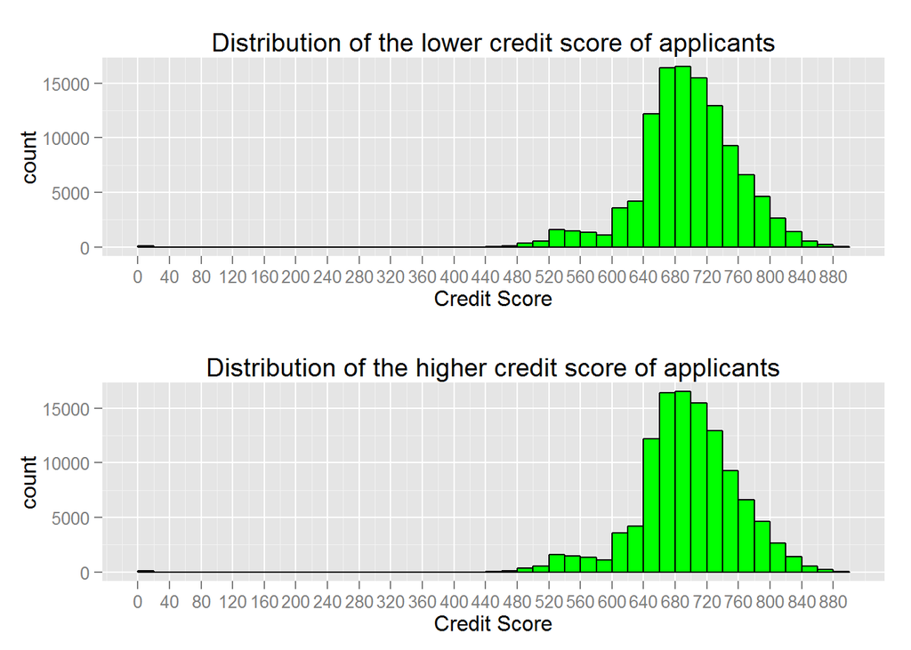

The distributions of the Credit scores (lower and upper) show a strong correlation. Therefore we will consider only one (CreditScoreRangeLower) in our analysis.

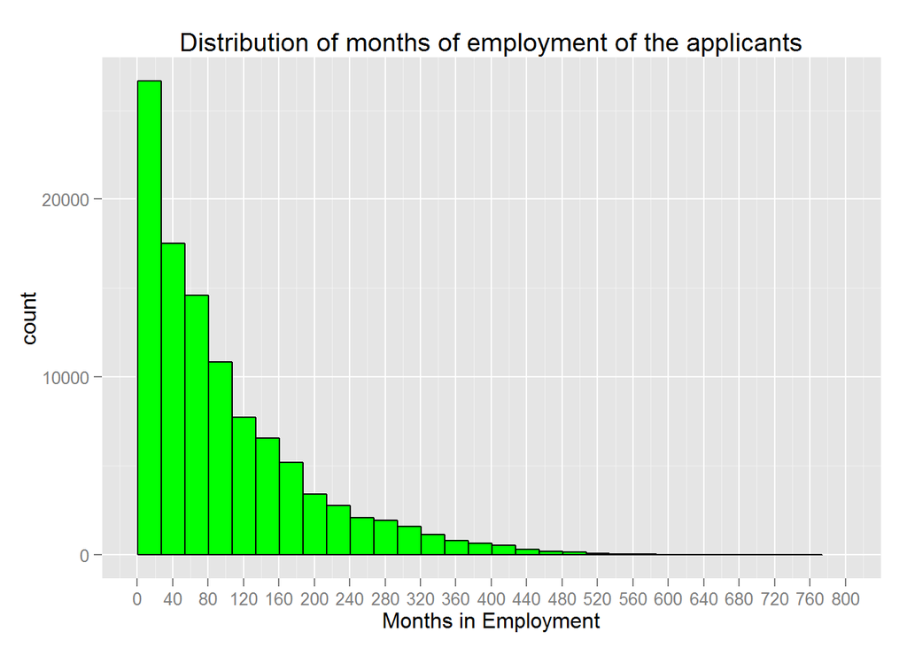

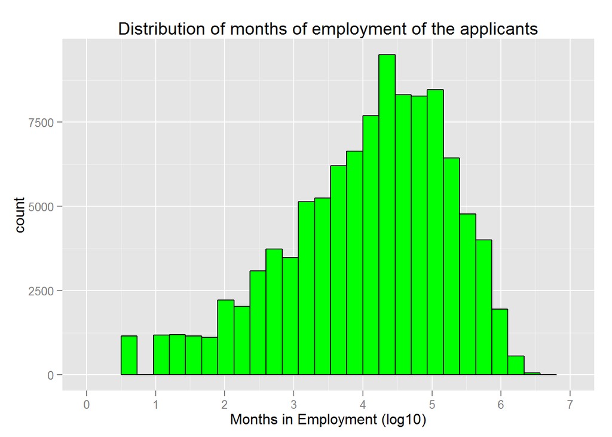

The employment status duration is measured in months. This distribution is positively skewed.Therefore I am plotting this on a log scale also. The log transformation is showing a more normal distribution. From this log transformed distribution we see that exp(4.4) which is ~82 months seems the most common employement duration.

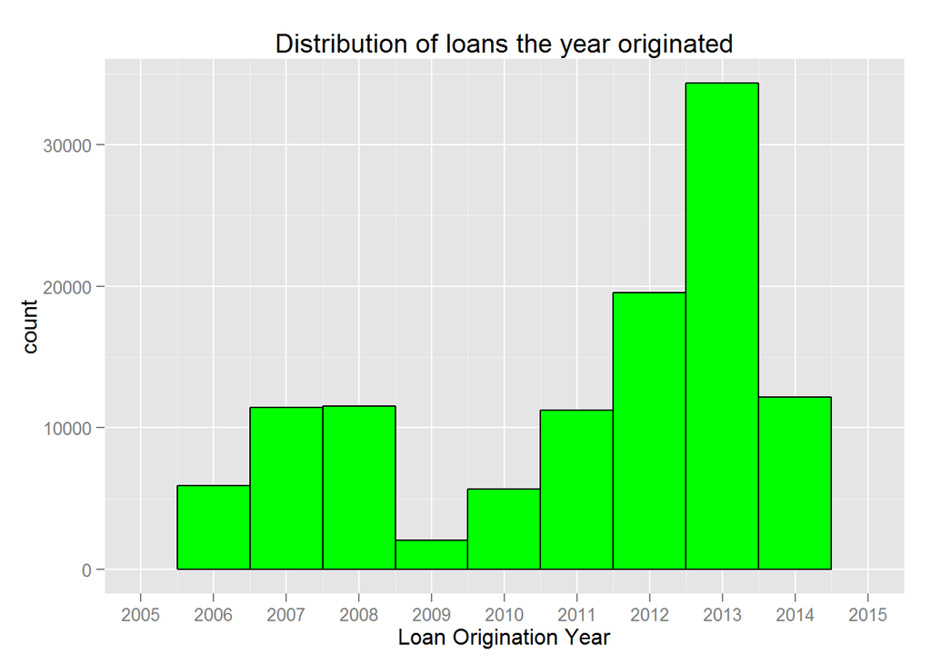

The distribution of the loans by the year shows that it is on increasing trend. There is dip in 2009 and after that the growth in number of loans is good. The dip in number of loans in 2014 is not really a dip as there is data only from the first quarter for 2014.

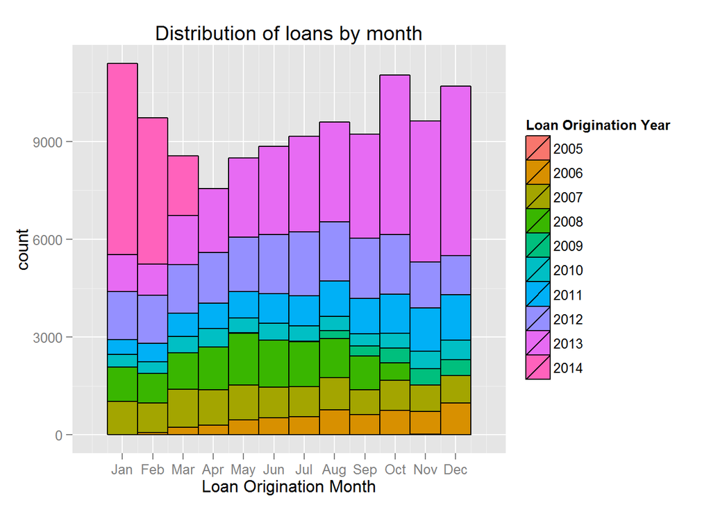

The distribution of the loans by the month they were originated in shows that the peak months are January and October. This increase also primarily because of loans originated in the years 2013 and 2014. The number of loans may have increased for holiday spending or due to aggressive marketing by Prosper loans. We can see that the number of loans in 2013 are increasing month by month. The maximum number of loans seem to have been originated in Jan 2014.

# Univariate Analysis

### What is the structure of your dataset?

The initial dataset consisted of 81 variables. In this I have chosen 20 variables for analysis.These have been listed at the top.

Among these 20 variables, 6 variables are categorical variables. These are LoanStatus, BorrowerState, IsBorrowerHomeowner, IncomeRange, LoanOriginationQuarter and LoanOrigination date.

The others are either number or integer variables.

### What is/are the main feature(s) of interest in your dataset?

The main features of interest in my dataset are the Loan status, Loan Origination date and monthly income. I am interested in how many are distributed over the year, their status and their relationship with the profile of the loan applicant. I am keen to investigate if the rules for loans have changed over the years.

### What other features in the dataset do you think will help support your investigation into your feature(s) of interest?

I have chosen all the variables to try and understand about the loans given by Prosper. Therefore features like credit score, income, debt to income ratio, employment duration is important to understand the type of applicant the loan is being given to. Feature such as Estimated Effective Yield, Prosper rating, listing category are useful in correlating with the loan status and loan applicant profile.

### Did you create any new variables from existing variables in the dataset?

I created three variables from existing variables. These are the month and year loan was originated. This was created from the LoanOriginationDate variable.

I also created another variable called NewDebtToIncomeRatio.This is the updated Debt to Income Ratio of the loanee after the loan is disbursed

### Of the features you investigated, were there any unusual distributions? Did you perform any operations on the data to tidy, adjust, or change the form of the data? If so, why did you do this?

I have 2 distributions as seen above which were positively skewed. These are for EmploymentStatusDuration and MonthlyLoanPayment. I applied log transformation on this data to check for the distribution. In both the cases, the log transformation helped in showing a more normal distribution. These helps us to visualize the values with highest count which is not possible with the distribution using the given value.

I have also changed some of the variables as factors or numeric when plotting them, so that I can plot them correctly.

# Bivariate Plots Section

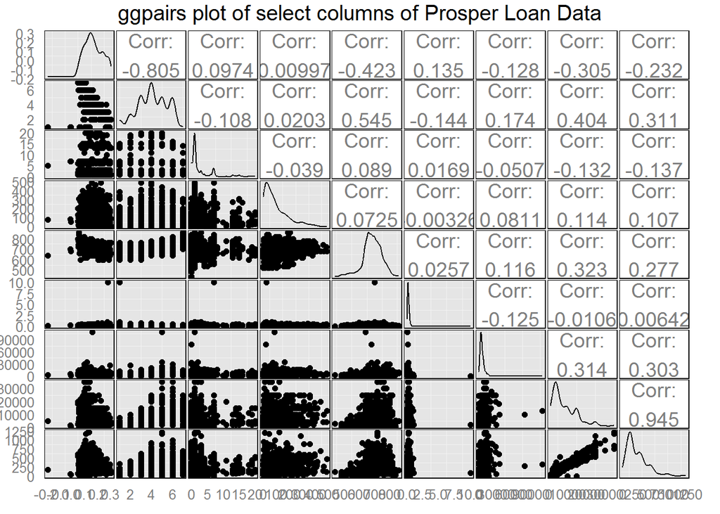

The ggpairs plot has been created for 9 variables - EstimatedEffectiveYield, ProsperRatingnumeric, ListingCategory, EmploymentStatusDuration, CreditScoreRangeLower, DebtToIncomeRatio, StatedMonthlyIncome, LoanOriginalAmount, MonthlyPayment. I have sampled 1000 entries to take a quick look.

We can see strong correlation between LoanOriginalAmount and MonthlyPayment.The Credit Score has normal distribution. It is interesting that the EstimatedEffectiveYield and ProsperRatingnumeric have a negative correlation. So better the rating, the effective yield is lesser (due to lower interest rate).

This plot is a good way to see quick relationships.

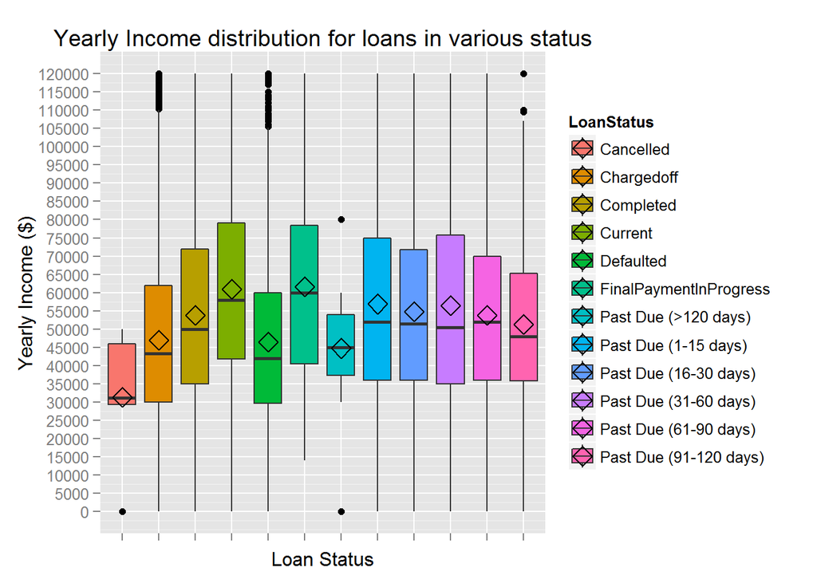

This plot to see if loan status depends on yearly income has been plotted. The monthly income has been converted to yearly income by multiplying with 12. It is very interesting to see that the loans in current and final payment in progress states have the highest median income. It can also be seen that as the status of the loan goes worse, the median income is coming down. As the median of current loans is higher than the median of completed loans, we can infer that the yearly income of borrowers from Prosper loans is increasing.

It is interesting to see that there a number of outliers (high income) who have loans in chargedoff or defaulted status. This number of outliers is significantly higher than for loans with other status.

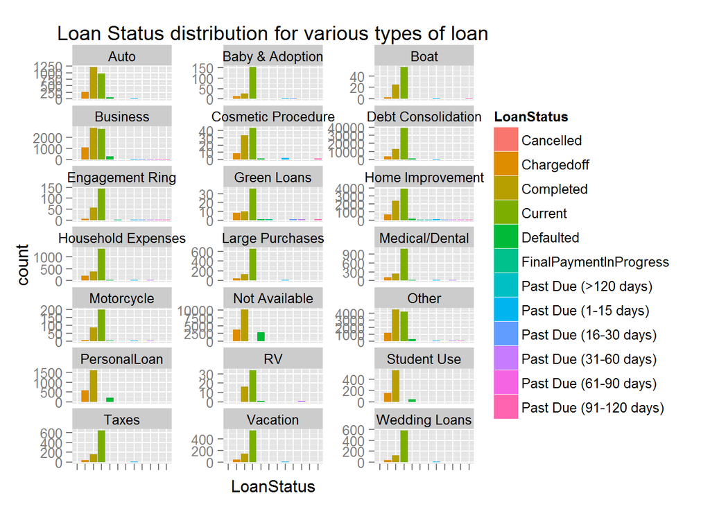

The debt consolidation loans are the highest type of loans. They are also significantly current in status. The number of current personal and student use loans have come down significantly.There are a number of loans in “Other” category. There are a number of loans in “Not Available” listing category.But as they are not current, it is possible that they are old loans.

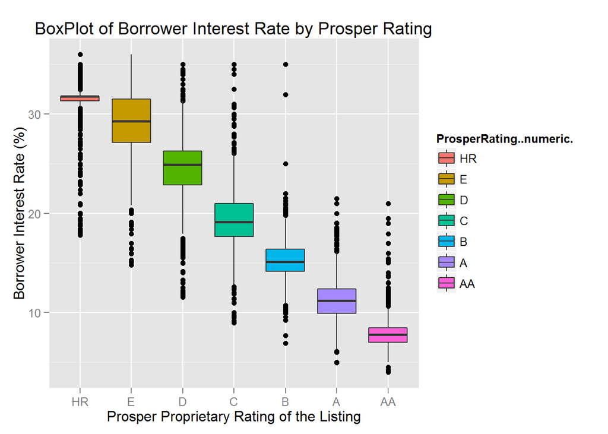

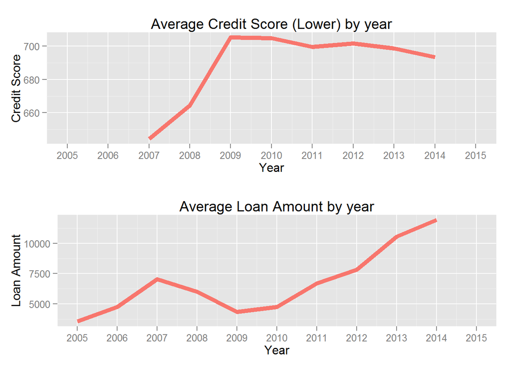

The average credit score by the year shows that the credit score of the borrowers increased significantly in 2009. Since then the mean has been gradually coming down.

The average loan amount has been significantly increasing from 2010. It has doubled from 2010 to 2014.

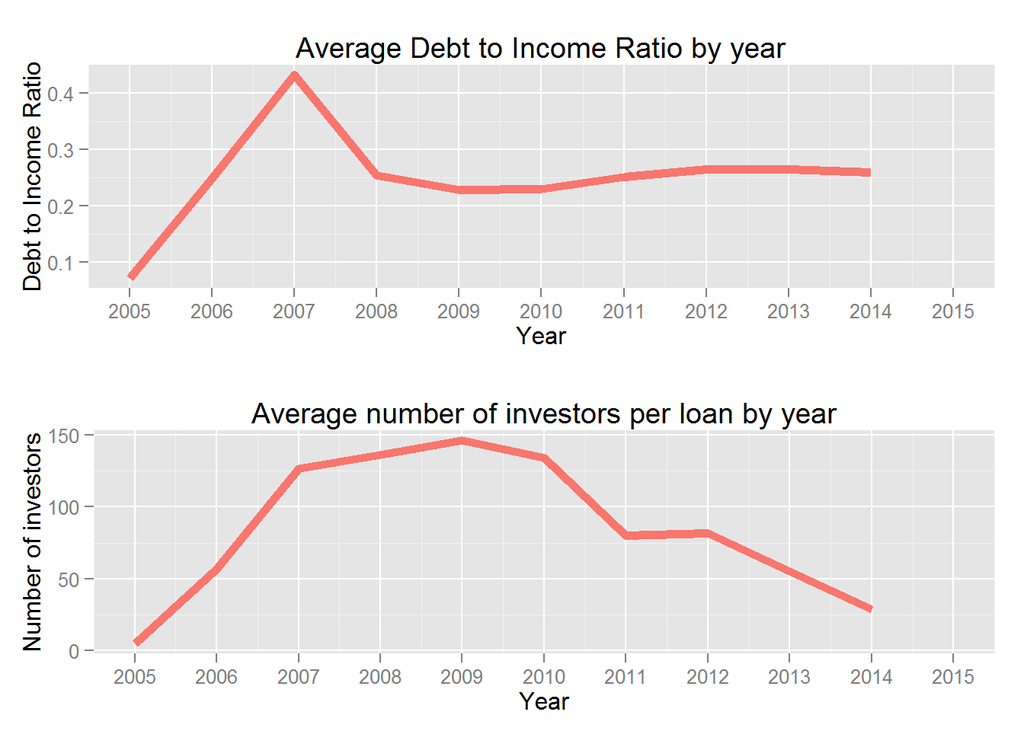

The average Debt to Income Ratio is in the range between 0.2 and 0.3. It was significantly higher in 2007 when it went over 0.4.

The number of investors per loan has come down in 2014 to below 50. In 2009 it was almost 150.

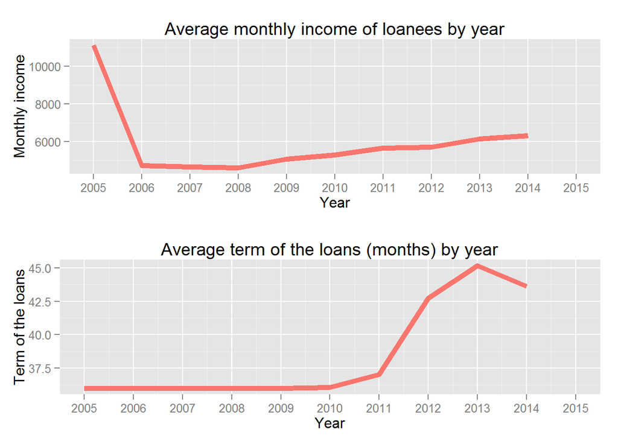

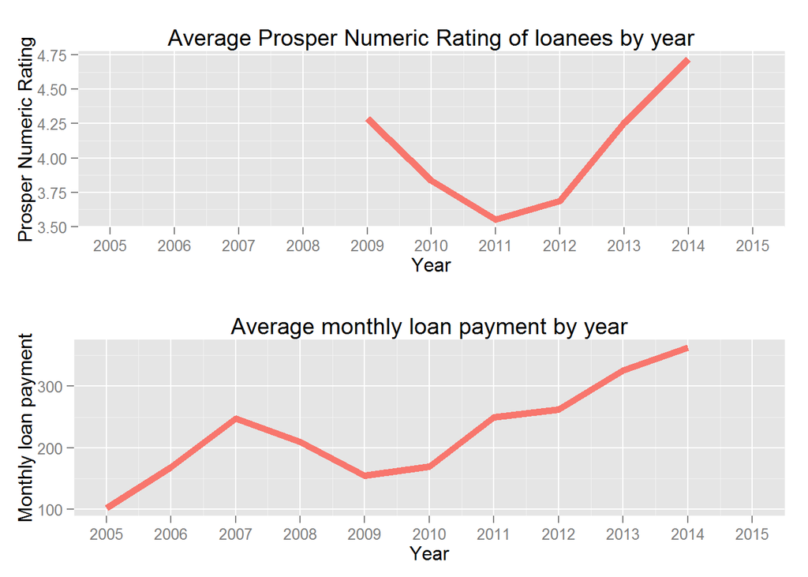

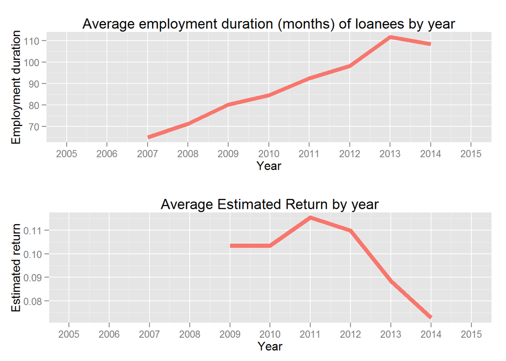

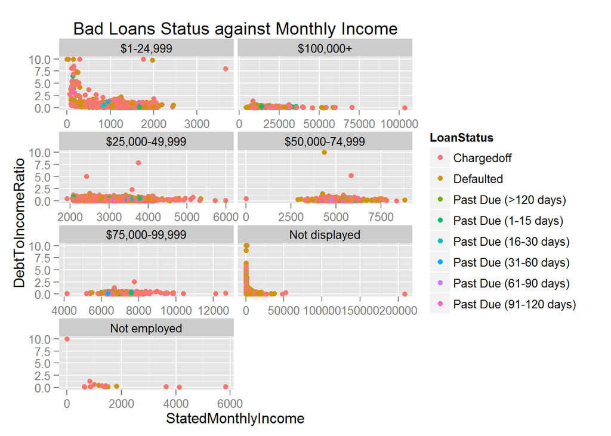

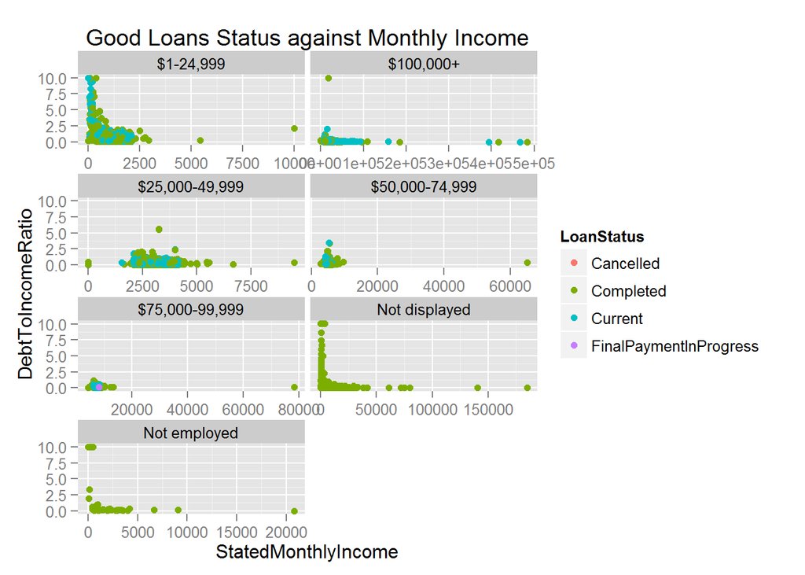

Most of the bad loans seem to be charged off. Therefore the quality of loans seems to be improving. It is interesting to see that in the income range of $1-$24,999 the Debt to Income Ratio was as high as 10.The behavior throughout the income range $25,000-$49,999 seems same. The bad loans are spread throughout the income range.

Again the Debt to Income ratio is high for good loans also for $1-$24,999 income range. The data for good loans shows that the income ranges have to corrected for many of the loans.

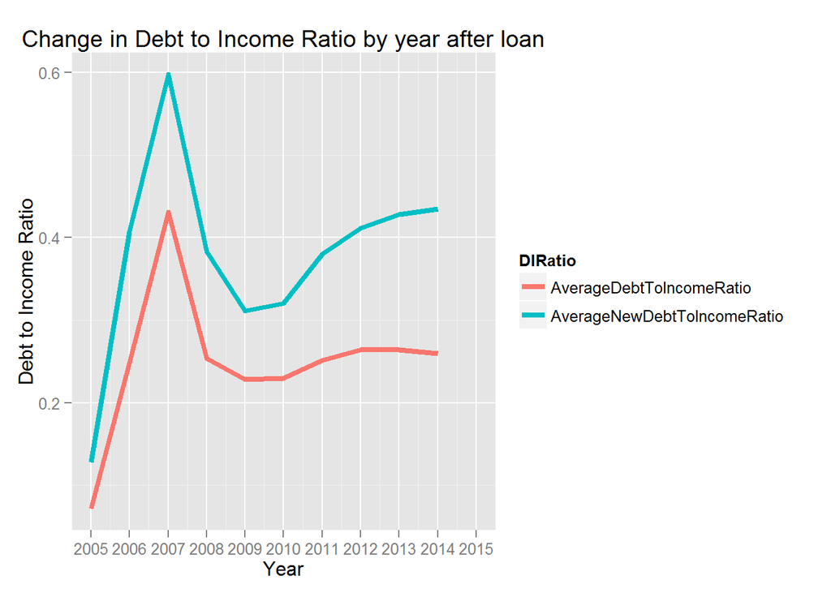

I plotted this graph to see how the Debt to Income ratio increases after the loan is taken. It increased a lot in 2007 and is again showing that is increasing by almost 0.2 in 2014.

# Bivariate Analysis

### Talk about some of the relationships you observed in this part of the investigation. How did the feature(s) of interest vary with other features in the dataset?

For me the most interesting was to see how the Debt to Income ratio of the borrower is increasing after taking the loan. This is showing an increasing trend of growing more. For loans in 2014 it has increased more. To me this is will be interesting to see if this will cause loans to go bad because of repayment requirements.

The plots of average per year showed interesting trend which made me realize that the quality of loans in Prosper in improving. The average rating of the loan is increasing while effective yield is reducing.

The average income of the borrower is increasing at a much lower pace than the average monthly payment. This again reinforces that the debt to income ratio is increasing. The average loan amount is also increasing.

### Did you observe any interesting relationships between the other features (not the main feature(s) of interest)?

I noticed that most of the bad loans are charged off loans. This means that while dataset has a number of bad loans, it is possible that the current portfolio of loans is quite strong with less number of bad loans. The income range variable needs cleaning up as it seems to have wrong monthly income. Some of the entries have “Not displayed” and “Not employed”. But these are also completed loans and therefore are not for current loans.

I have not done any analysis on the Investors. But it is an interesting observation that the average number of investors is coming down significantly. This means that there is more confidence in Prosper Loans and investors are willing to lend larger sum of money (as average loan amount is also increasing).

### What was the strongest relationship you found?

# Multivariate Plots Section

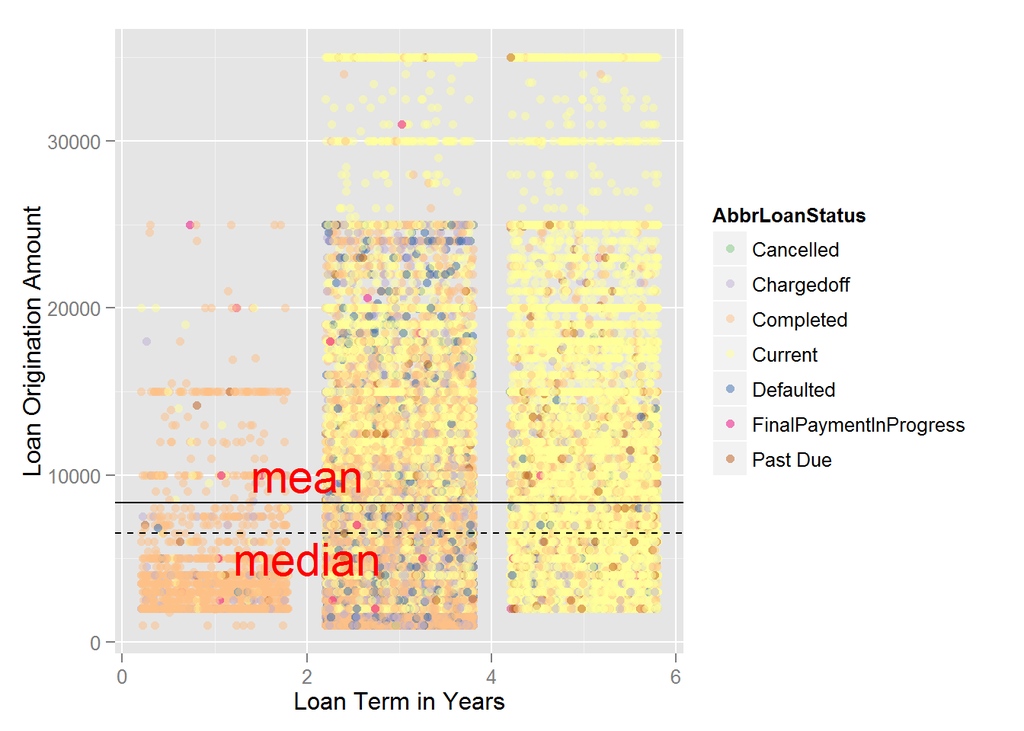

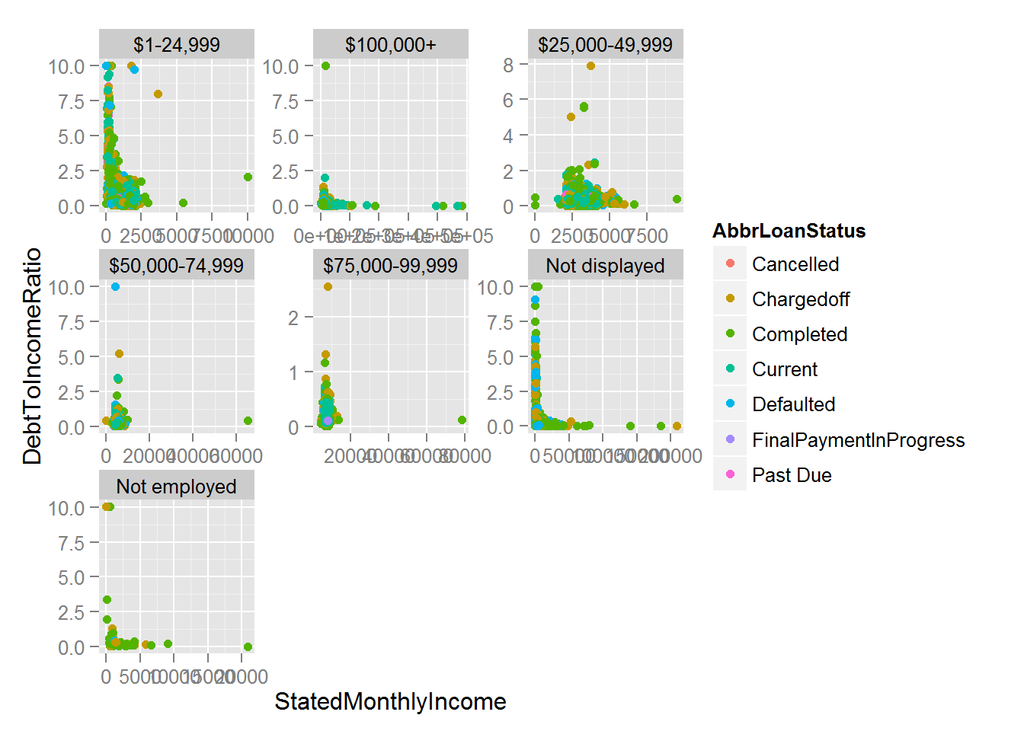

# Multivariate Analysis

### Talk about some of the relationships you observed in this part of the investigation. Were there features that strengthened each other in terms of looking at your feature(s) of interest?

I also plotted the Debt to Income ratio against the monthly income and colored by loan status to see if we can predict the loan status. It was interesting that the loans in $1-$24,999 were positively skewed. It looks apparent that the defaulted loans had either high debt to income ratio or low income.

### Were there any interesting or surprising interactions between features?

The mean and median of the loan origination amount is based on all historical data which may not be relevant. The current loans have significantly higher loan amounts, and the mean of them is probably much higher.

### OPTIONAL: Did you create any models with your dataset? Discuss the strengths and limitations of your model.

# Final Plots and Summary

### Plot One

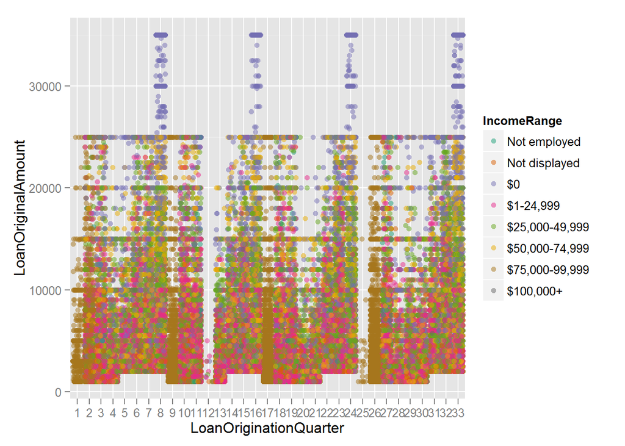

### Description One

In this plot I have plotted the loan amount to the quarter it was originated. The plot is colored by the income range of the borrower. I thought of this plot to see if Prosper has changed at all over the years about looking into income range while giving a loan and determining the amount.

### Plot Two

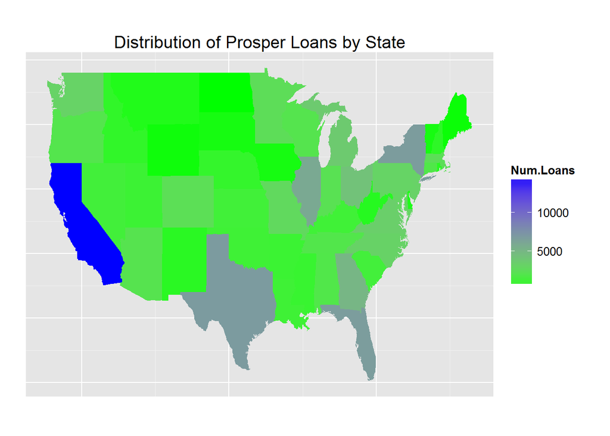

### Plot Three

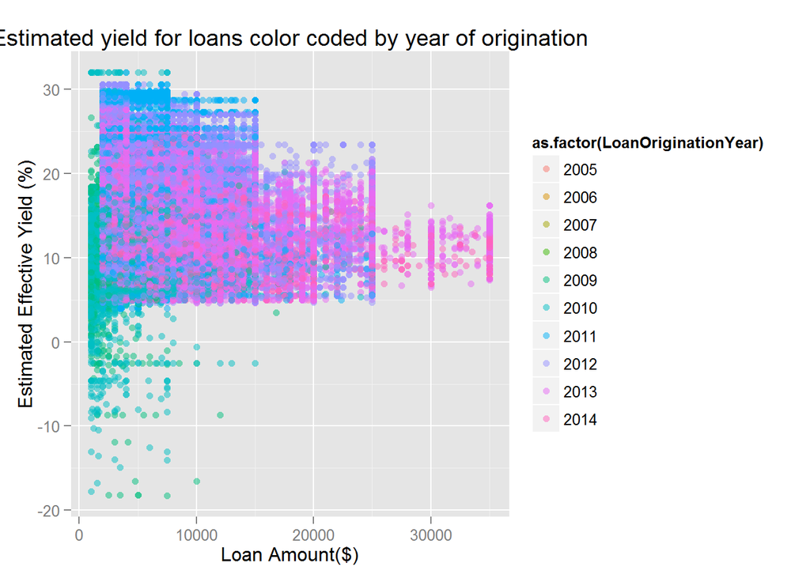

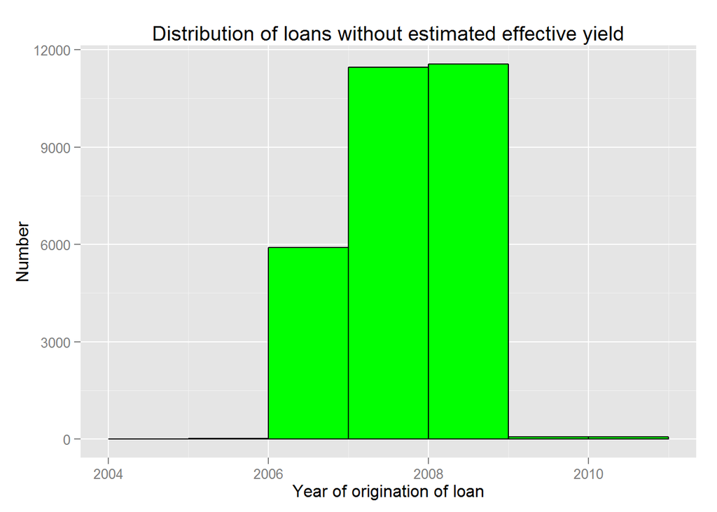

### Description Three

There were a number of loans without estimated effective yield. So I drew a graph of them and saw that these are loans that belong in the time 2006-2009. All the new loans have this data.

# Reflection

This was an interesting exercise. At the end of it, I felt have barely scratched the surface after spending so much time in analysis. There are so many variables I have not even looked at. I have also not drawn any model to check. The concept of project is good, as it made me try and correct all graphs by the rubric.

The analysis made me understand how the loans are given and the factors that affect the interest rate, loan amount. I have not analysed any variables about the past credit history. These are the areas to look into and try and see if we can predict the loan status. This is the area I would concentrate next on.

I have also realized that we have to condense factors to less than 8 levels to be able to properly visualize. I have done this for loan status where I have put together all past due loans as one.

Further there are a large number of current loans. I think all the variables have to be recalculated for these, as past data may be skewing the results (as seen for average loan origination amount).